# scMAGeCK-Visualization Tutorial

Lin Yang

04/16/2020

## Standard pre-processing workflow

The steps below briefly demonstrate the pre-processing workflow for RDS file in scMAGeCK

1. Convert the sgRNA count into sgRNA distribution matrix
2. For the data normalization, we choose the centered log-ratio (CLR) recommended in Seurat R package
3. Integrate the sgRNA information into RDS file for further analysis

```r
library(scMAGeCK)
library(Seurat)
library(ggplot2)

# Load the Demo dataset
BARCODE <- system.file("extdata","barcode_rec.txt",package = "scMAGeCK")
RDS <- system.file("extdata","singles_dox_mki67_v3.RDS",package = "scMAGeCK")
# Pre-process sgRNA count from previous step, and generate the sgRNA expression matrix.
Demo <- pre_processRDS(BARCODE = BARCODE, RDS = RDS)
```

## Visualization

scMAGeCK mainly focuses on analyzing the cells that only have one type of sgRNA at this time. Therefore, we filtered out the undesired cells based on the sgRNA distribution plot.

```
## Cell names in expression matrix and barcode file do not match. Try to remove possible trailing "-1"s...
```

```
## 1006 cells entered sgRNAs have been filtered out in RDS file
```

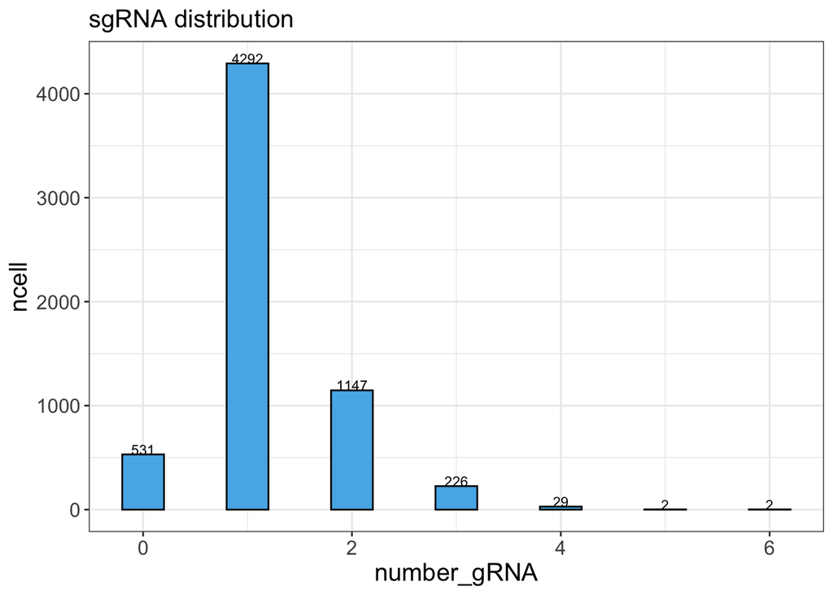

```r
# Visualize the sgRNA distribution accross dataset
featurePlot(BARCODE = BARCODE, RDS = Demo, TYPE = "Dis")
```

Some datasets would have a preference for the sgRNA distribution. In that case, limited the gene expression comparison in that clusters can improve the results.

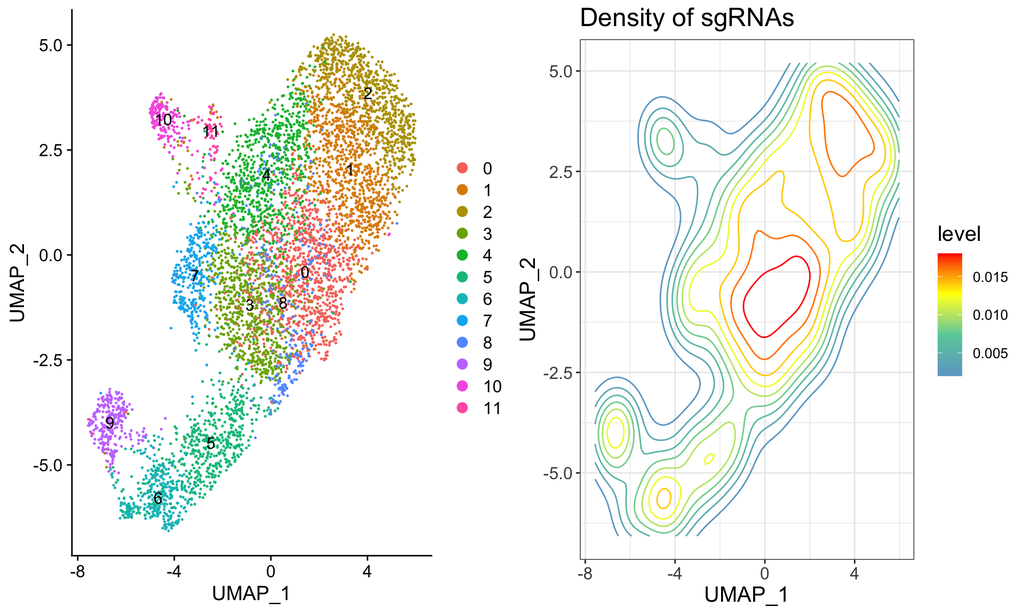

```r
# Optional function
library(gridExtra)

# RDS file needed to finished clustering step.
Demo <- RunUMAP(Demo, dims = 1:10)
plot1 <- DimPlot(Demo, reduction = "umap", label = TRUE)

# Visualize the Density of sgRNA accross dataset
# It would show the density of specific sgRNAs if set the sgRNA
# Multiple sgRNAs can be provided, separated by ",". For example, "APC,TP53"
plot2 <- featurePlot(RDS = Demo, sgRNA = NULL, TYPE = "Den")
grid.arrange(plot1, plot2, ncol = 2)
```

## Use two main functions of scMAGeCK

```r
# RRA test
# Set the path to the RRA program, if RRA cannot be found in the PATH environment variable.
RRAPATH="/Users/linyang/Library/RRA_0.5.9/bin/RRA"

# Use gene MKI67 as an example
rra_result <- scmageck_rra(BARCODE=BARCODE, RDS=RDS, GENE="MKI67",
                               RRAPATH=RRAPATH, LABEL='dox_mki67',
                               NEGCTRL=NULL, KEEPTMP=FALSE, SIGNATURE = NULL,
                               PATHWAY=FALSE, SAVEPATH=NULL)
# LR test
lr_result <- scmageck_lr(BARCODE=BARCODE, RDS=RDS, LABEL='dox_scmageck_lr', SIGNATURE = NULL,
      NEGCTRL = 'NonTargetingControlGuideForHuman', PERMUTATION = 1000, SAVEPATH=NULL, LAMBDA=0.01)
```

## Visualize the gene regulation relationship by using RRA or LR test.

The second RRA result (RRA_re2) from the scmageck-rra step can be added to visualize gene selection under two different cell conditions.

Multiple genes can be provided, separated by “,”. For example, “APC,TP53”. For the LR test, however, selection plot only shows the significant results when applied multiple genes.

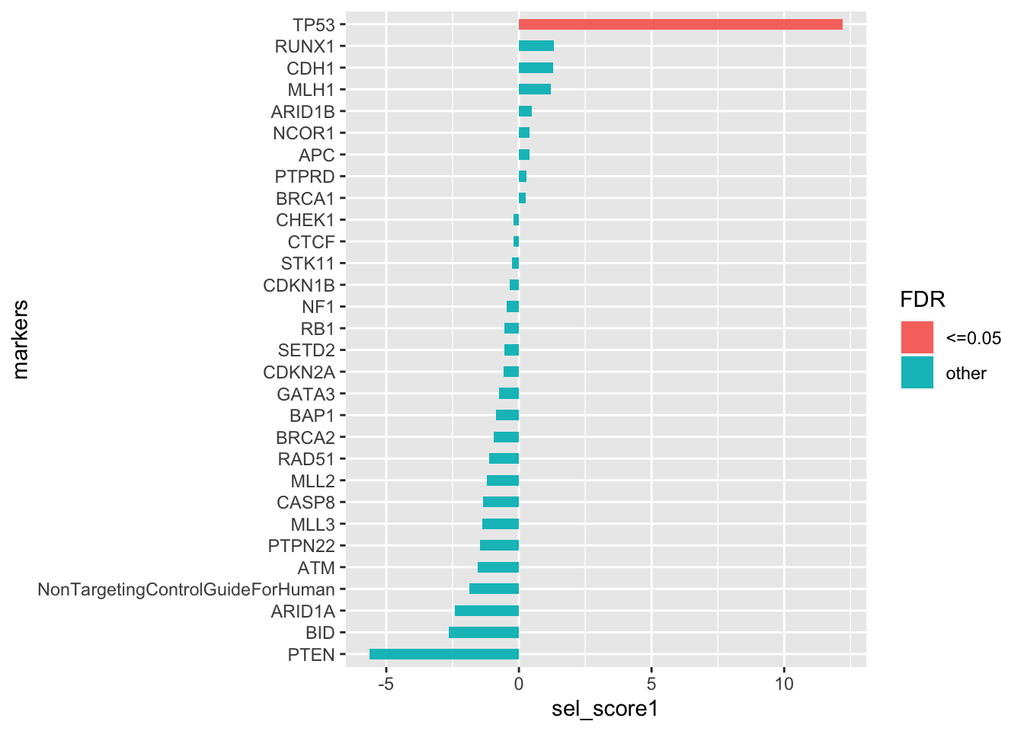

```r
# identify significant sgRNA which affect gene MKI67 by using RRA test
selectPlot(RRA_re1 = rra_result, RRA_re2 = NULL, CUTOFF = 0.05, QUALITY = 10, TYPE = "rra")
```

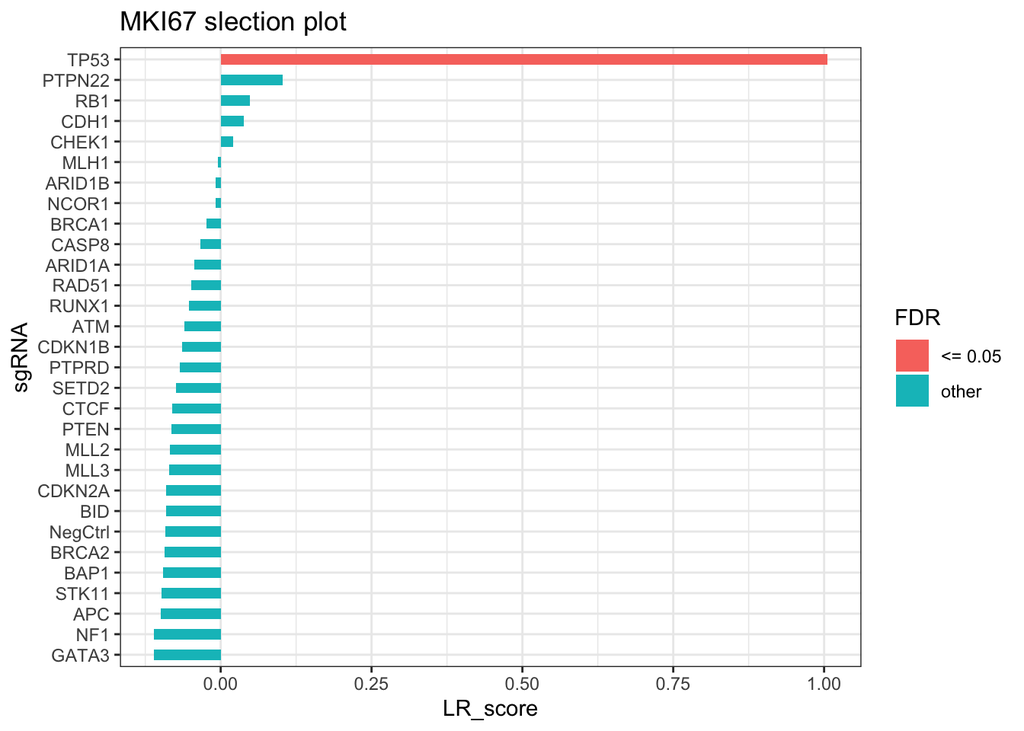

```r
# identify significant sgRNA which affect gene MKI67 by using LR test
selectPlot(GENE = "MKI67", lr_result = lr_result, CUTOFF = 0.05, ADJ = "fdr", TYPE = "lr")
```

Use the violin plot to show gene expression change between cells that knockout specific genes and other cells. Multiple genes can be provided, separated by “,”. For example, “APC,TP53”. When providing multiple genes, it would show the average gene expression.

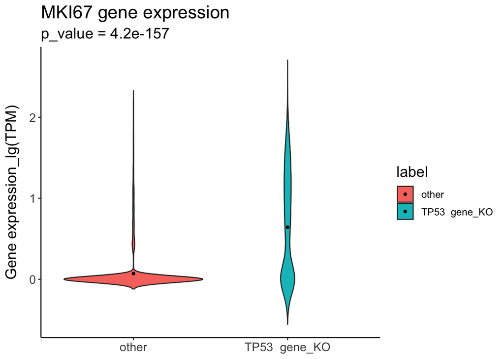

```r
# Visualize the true gene regulation in the dataset
featurePlot(RDS = Demo, GENE = "MKI67", sgRNA = "TP53", TYPE = "Vln")
```